# Final Project - Population Genetic Structure of the Sea Urchin Tripneustes gratilla

Author

Leah Barkai

Published

December 2, 2025

# Introduction

This document is for my final project on population genetics of *Tripneustes gratilla* with data received from [Genbank](https://www.ncbi.nlm.nih.gov/nuccore). A total of 222 unique GenBank submissions were curated for this project. Each entry was confirmed to contain both a high-quality Cytochrome Oxidase I (COI) sequence and corresponding geographic location data.

### Research Question:

Is there genetic population structure in *Tripneustes gratilla* across its sampled Indo-Pacific range?

Population structure is the non-random distribution of genetic variation within a species, showing that the population is subdivided rather than being one freely interbreeding group.

In a structured population, this division is typically caused by one or more of the following factors:

- Limited Gene Flow: Physical barriers (such as ocean currents, landmasses, or immense distance) restrict the movement and interbreeding of individuals.
- **Genetic Drift:** The random change in allele frequencies, which is often amplified within small, isolated populations.
- **Local Adaptation:** Natural selection favoring different heritable traits in distinct local environments, reinforcing genetic differences between populations.

## Load Libraries

These are the libraries I used to complete this assignment.

```r
### Core Libraries Used (Setup, and Data Handling)
library(tidyverse) # Includes ggplot2, readr, dplyr, tidyr
library(knitr)     # For general knitting options
library(here)      # For reliable file path construction
library(readr)     # For reading the cleaned data
library(dplyr)     # For general data manipulation

### Libraries for Output 1: Interactive Table (DT)
library(DT)        # For creating the interactive datatable()
library(htmltools) # Needed to render HTML captions/titles in DT
library(stringr)   # Useful for string manipulation in table prep

### Libraries for Output 2: Structure Bar Plot (DAPC & Phylogenetics)
library(Biostrings) # For handling DNA sequences (DNAStringSet)
library(msa)        # For sequence multiple alignment (ClustalW)
library(ape)        # For sequence data structure (as.DNAbin)
library(adegenet)   # For DAPC and genind objects
library(ade4)       # Underlying package for PCA/DAPC
library(ggplot2)    # For plotting the final bar plot
library(ggtext)     # For advanced text formatting (e.g., italics in titles)

### Libraries for Output 3: Map
library(sf)             # For working with spatial features
library(rnaturalearth)  # For global map boundaries
library(rnaturalearthdata) # For detailed map data
library(ggrepel)        # For labeling points on the map without overlap
```

## Data Preparation and Cleaning

The dataset was curated from publicly available **GenBank** submissions. Initial screening ensured that all records contained the necessary metadata, specifically **COI (Cytochrome Oxidase Subunit I) sequences**, along with associated **collection dates** and **geographic locations**.

I loaded and cleaned this raw data using a script (ask author Leah Barkai for script). This script prepared the *Tripneustes gratilla* COI sequence data for downstream genetic analysis by performing the following core steps:

**What I Did to Clean My Data:**

- Read each GenBank file into R as a character vector
- Used a loop to extract each record between **LOCUS** and **//**
- Extracted metadata fields: **Locus**, **Date**, **Country**, **Coordinates**, **Species**, **Sequence**
- Cleaned sequences by:
  - Removing all numbers and whitespace
  - Converting to uppercase letters
  - Removing non-DNA characters (kept only **A, C, G, T, N = unknown nucleotide**)
  - Keeping only sequences between **550–700 bp** Cleaned metadata by:
- Cleaned metadata by:
  - Standardizing country names (correcting mislabeled regions)
  - Ensuring the **Species** column existed even when missing
  - Removing known problematic/outlier sequences (e.g., MK609485)
- Cleaned dates by:
  - Pulling dates from `/collection_date` first
  - Using `/date` or the LOCUS line if missing
  - Formatting everything to **YYYY-MM-DD**
- Final data preparation:
  - Removed duplicate Locus entries
  - Removed rows missing Country
  - Combined all cleaned datasets into one table
  - Saved output as **Cleaned_Tripneustes_CO1_Data.csv**

# Read in Data

```r
Tripneustes_C01_data <- read_csv(here("Data", "Cleaned_Tripneustes_CO1_Data.csv"))

glimpse(Tripneustes_C01_data) #Glimpse of the data
```

```
Rows: 222
Columns: 5
$ Locus             <chr> "AY205374", "AY205375", "AY205392", "AY205393", "AY2…
$ Collection_Date   <date> 2016-07-25, 2016-07-25, 2016-07-25, 2016-07-25, 201…
$ Sequence          <chr> "ATCCTATTTCAACATCTATTCTGATTTTTTGGTCACCCGGAAGTCTACATC…
$ Sampling_Location <chr> "Chile", "Chile", "Chile", "Chile", "Chile", "Chile"…
$ Species           <chr> "Tripneustes gratilla", "Tripneustes gratilla", "Tri…
```

# Data Dictionary

The following table serves as the **Data Dictionary**, defining the variables contained in the dataset used for analysis. This information is sourced from the file **`Final_Project_Data_Dictionary.csv`**.

[output not shown]

# Output #1: Interactive Table

This output provides an interactive representation of the cleaned T*ripneustes gratilla* sequence dataset, allowing for dynamic viewing, filtering, and sorting of the COI records and associated metadata.

```r
# 1. Prepare data by shortening sequences for table display
Data_Table <- Tripneustes_C01_data %>% # Table of Data
  mutate(Sequence_Short = paste0(      # Creating new column to have first 50 sequences showing
    "<span title='", Sequence, "'>",   # Able to expand the sequence to see the whole thing
    substr(Sequence, 1, 50),           # First 50 characters
    ifelse(nchar(Sequence) > 50, "...", ""), # Seeing how long the sequence is
    "</span>")) %>%                    # Closing the span tag
  select(Locus, Collection_Date, Sequence_Short, Sampling_Location) # Using these columns for the table

# 2. Table caption
table_caption <- tags$caption(            # Making table caption
    style = 'caption-side: top; text-align: left;', # Location of caption
    HTML("Table 1: GenBank Sequence Records for <i>Tripneustes gratilla</i> (Hover over the sequence to view the full length.)") # Caption to tell people they can hover over it to get the full thing
)

# 3. Make the interactive datatable
datatable(Data_Table,                    # Creating the interactive table
          escape = FALSE,                # Allow rendering
          rownames = FALSE,              # Hide row names
          colnames = c(                  # Column header names that I put in the data dictionary
            "Sequence ID Number",
            "Collection Date",
            "CO1 DNA Sequence",
            "Sampling Location"),
          options = list(                # Table set up
            pageLength = 10,             # 10 rows per page
            autoWidth = TRUE,            # Width adjustment
            scrollX = TRUE,              # Allow horizontal scrolling
            columnDefs = list(           # Column widths
              list(width = '10%', targets = c(0, 1)),
              list(width = '40%', targets = 2))),
          caption = table_caption)        # Add caption
```

[output not shown]

[output cut: 212 more lines]

Table 1. Sample locations were compiled from GenBank and published literature. The reported geographic level varies, including countries, territories, and provinces, representing the finest resolution available for each sample.

# Output #2: Genetic Structure Bar Plot

Code to make the elbow plot:

```r
# 1. Data Cleaning
dapc_df <- Tripneustes_C01_data %>% #Making a new data frame
# Start with raw data frame
  filter(!is.na(Sequence), Sequence != "") %>% # Remove rows with NAs, missing or empty
  mutate(Individual_ID = paste0("Seq_", row_number()), #Unique ID for each sequence
         Original_Locus = Locus) #Use the sequence ID number aka the locus

seqs <- DNAStringSet(dapc_df$Sequence) #Converting sequence column to DNAStringSet object (required for alignment)
names(seqs) <- dapc_df$Individual_ID # Name the sequences using the new unique Individual_ID

# 2. Alignment - just a heads up - this can take a while to perform
aln <- msa(seqs, method="ClustalW", substitutionMatrix=NULL, verbose=FALSE) # Perform Multiple Sequence Alignment (MSA) using ClustalW
```

```
use default substitution matrix
```

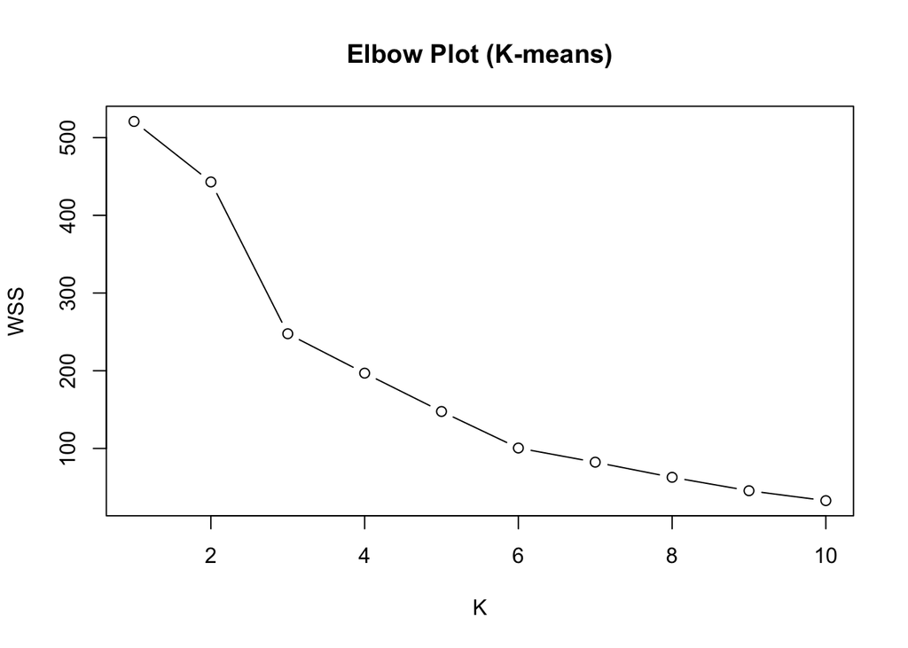

```r
          # Does pairwise alignment which algins two sequences at a time then calculates a score to see how similar the pair is
bin <- as.DNAbin(aln) # Convert alignment output to DNAbin format (required for 'adegenet' package)

# 3. Genind - object that is designed to hold indidivual genetic info alongside metadata
gen <- DNAbin2genind(bin, # Convert DNAbin to genind object
                     pop = dapc_df$Sampling_Location) # Grouping by sampling location

# 4. Checking
if (nInd(gen) != nrow(dapc_df)) #Checking if individual counts in genind match input rows
  stop("Mismatch between genind individuals and input rows") #Stop if mismatched

var_sites <- sum(apply(gen@tab, 2, function(x) length(unique(x)) > 1)) #Checking variation - number of variable sites
if (var_sites < 5) stop("Too few polymorphic sites for DAPC") #Stop if too few sites

gen@tab <- tab(gen, NA.method="mean") #

# Impute missing genotypes with the mean allele frequency

# 5. PCA Analysis and Elbow plot
pca_out <- dudi.pca(gen, scale=FALSE, # Run Principal Component Analysis (PCA) on genind object
                    nf=10, scannf=FALSE) # Retain 10 Principal Components (PCs) for clustering

max_k <- 10 # Set the maximum number of clusters (K) to test
wss <- sapply(1:max_k, function(k){ # Calculate Within Sum of Squares (WSS) for K-means clustering
  kmeans(pca_out$li, centers=k, nstart=20)$tot.withinss # WSS for each K from 1 to max_k, based on PCA scores
})

plot(1:max_k, wss, type="b", xlab="K", ylab="WSS", #View plot
     main="Elbow Plot (K-means)")
```

```r
# Selecting K = 3 because that's the point where adding more groups stops being significantly useful, based on the Elbow Plot - basically where you see an elbow in your plot

optimal_k <- 3 # Manually set the optimal number of clusters chosen from the Elbow Plot

# 6. Final structure bar plot
km <- kmeans(pca_out$li, centers=optimal_k, nstart=20) # Run K-means clustering on the PCA scores

dapc_res <- dapc(gen, pop=factor(km$cluster), n.pca=10, n.da=optimal_k-1) # Check how well these groups separate using the full genetic data

plot(1:max_k, wss, type="b", xlab="K", ylab="WSS", #Plot with the scores and K group
     main="Elbow Plot (K-means)")
```

Code to make the structure bar plot:

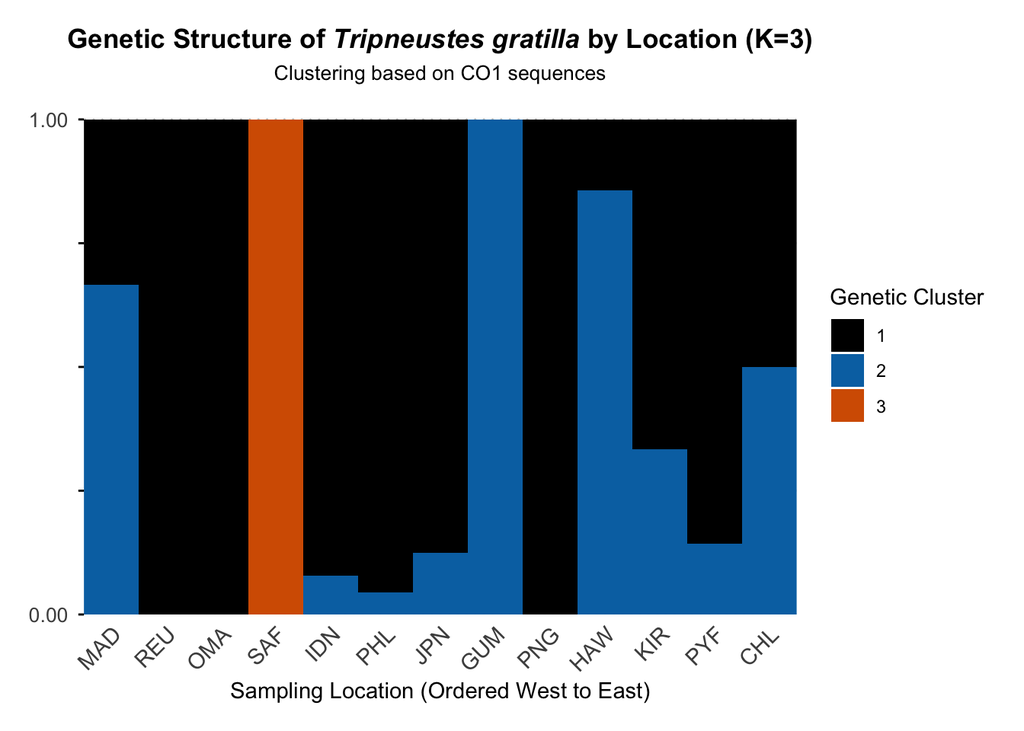

```r
# 1. Converting DAPC results into a long tidy format for plotting
assignments_long <- as.data.frame(dapc_res$posterior) %>% #Taking the cluster probabilities from DAPC
  tibble::rownames_to_column("Individual_ID") %>% #Turning IDs into a column
  pivot_longer( #Changing from wide to long format
    cols = -Individual_ID, # Taking all columns except Individual_ID
    names_to = "Cluster", #New column name for cluster number
    values_to = "Membership_Prob" ) %>% # New column name for probability score (0 to 1)
  left_join(dapc_df %>% select(Individual_ID, Sampling_Location), by = "Individual_ID") %>%
  mutate(Cluster = as.integer(Cluster)) # Adding location data to the probabilities

# 2. Data prep for plot
custom_location_order <- c( #Listing the sampling locations from West to East
  "Madagascar", "Reunion (France)", "Oman", "South Africa",
  "Indonesia", "Philippines", "Japan", "Guam", "Papua New Guinea",
  "Hawaii", "Kiritimati", "French Polynesia", "Chile")
abbreviation_map <- data.frame( #Assigning abbreviations to the locations so not so much going on
  Sampling_Location = custom_location_order,
  Abbreviation = c("MAD", "REU", "OMA", "SAF", "IDN", "PHL", "JPN", "GUM", "PNG", "HAW", "KIR", "PYF", "CHL"))

# 3. Calculating average genetic composotion for each sampling location
mean_assignments_loc <- assignments_long %>%
  dplyr::group_by(Sampling_Location, Cluster) %>%
  dplyr::summarise(Mean_Membership_Prob = mean(Membership_Prob), .groups = "drop") %>%
  dplyr::mutate(Sampling_Location = factor(Sampling_Location, levels = custom_location_order)) %>%
  dplyr::left_join(abbreviation_map, by = "Sampling_Location") %>%
  dplyr::mutate(Abbreviation = factor(Abbreviation, levels = abbreviation_map$Abbreviation))

# 4. Making the plot settings
plot_title <- paste0("Genetic Structure of *Tripneustes gratilla* by Location (K=", optimal_k, ")") #Title
plot_subtitle <- "Clustering based on CO1 sequences" #Subtitle

# Define custom colors for each cluster - colors are color blind friendly
cluster_colors <- c("1" = "#000000",  # black
                    "2" = "#0072B2",  # blue
                    "3" = "#D55E00")  # orange

# 5. Putting the plot all together
simplified_structure_plot <- ggplot2::ggplot(
  mean_assignments_loc %>% mutate(Cluster = factor(Cluster)), # Start plot with mean assignment data
  aes(x = Abbreviation, y = Mean_Membership_Prob, fill = Cluster)) + # Map location to X, probability to Y, and cluster to color
  ggplot2::geom_bar(stat = "identity", width = 1) +          # Draw stacked bars (height based on Y value); width=1 removes gaps
  ggplot2::scale_fill_manual(values = cluster_colors) +      # Colors defined before
  ggplot2::scale_x_discrete(expand = c(0, 0)) +              # Remove padding on the X-axis
  ggplot2::scale_y_continuous(                               # Setting for Y-axis
    expand = c(0, 0),                                        # Remove padding on the Y-axis
    limits = c(0, 1.05),                                    # Set Y-axis to go slightly above 1
    breaks = seq(0, 1, by = 0.25),                          # Set major tick marks at 0, 0.25, 0.5, 0.75, 1
    labels = c("0.00", "", "", "", "1.00")) +               # Only label the 0 and 1 points clearly
ggplot2::labs(
  title = plot_title,                                       # Add title
  subtitle = plot_subtitle,                                 # Add subtitle
  x = "Sampling Location (Ordered West to East)",         # Label X-axis
  y = NULL,                                               # Set Y-axis label to be empty
  fill = "Genetic Cluster") +                             # Label color legend
  ggplot2::theme_minimal() +                                # Clean minimal theme
  ggplot2::theme(
    plot.title = ggtext::element_markdown(hjust = 0.5, face = "bold"), # Center and bold the plot title
    plot.subtitle = element_text(hjust = 0.5, size = 10),
    axis.text.y = element_text(size = 10),
    axis.ticks.y = element_line(linewidth = 0.5, colour = "black"),
    axis.text.x = element_text(angle = 45, hjust = 1, size = 11), # Rotate X-axis labels for better fit
    panel.grid.major.y = element_line(color = "gray80", linetype = "dotted"), # Keep faint horizontal grid lines
    panel.grid.minor.y = element_blank(),
    panel.grid.major.x = element_blank(),                   # Remove vertical grid lines
    plot.margin = unit(c(0.5, 0.5, 0.5, 0.5), "cm"))

#5. Save plot
ggplot2::ggsave(
  filename = "structure_plot_simplified_mean_loc.png",
  plot = simplified_structure_plot, #Name
  path = here::here("Output"), # Use here function to save
  width = 8, height = 5, units = "in")

# 6. Display the plot
plot(simplified_structure_plot)
```

**Figure 1. Mean Genetic Structure of *Tripneustes gratilla* by Location (**$K=3$**).** The Y-axis represents the Mean Membership Probability (Admixture Proportion), where the height of each colored segment indicates the average proportion of the assigned genetic cluster in that respective sampling location. Abbreviations (West to East): MAD, Madagascar; REU, Reunion (France); OMA, Oman; SAF, South Africa; IDN, Indonesia; PHL, Philippines; JPN, Japan; GUM, Guam; PNG, Papua New Guinea; HAW, Hawaii; KIR, Kiritimati; PYF, French Polynesia; CHL, Chile. Data Source: GenBank CO1 Sequences.”